Rova Ralaimidona · irova@me.com

Audit qualité des données Cartofriches – Phase EDA & Nettoyage

## 📌 Objectif

Cartofriche est un inventaire recenssant les données des friches en France, celle ci contient:

- une application cartographique interactive affichant la liste des friches par zones et leur statuts avec projets en cours ou non, avec `14 986` données complétées, et des donnees interactives textuelles complétant les informations.
- Les [données agrégées](https://explore.data.gouv.fr/fr/datasets/61892a26c94e39bde1dbf7ac/#/resources/74feb3ed-5f9f-4ef8-8fab-b0128d569a99) sous forme de tableau contenant `28115 lignes`.
- Et enfin les données issues des [différents observatoires](https://cartofriches.cerema.fr/cartofriches/_w_777b948092254103afafe6b2114df906/_w_6f3680e8d5044ce29946e063c0927df3/). `7239 lignes`

Ce notebook vise à :

- Évaluer la qualité des données (complétude, unicité, actualité, etc.) ;
- Identifier les valeurs manquantes, doublons et éventuelles incohérences ;
- Comprendre les écarts entre la carte interactive et les jeux de données tabulaires ;
- Identifier les variables cibles et préparer les données à des analyses statistiques ou des modèles prédictifs, le cas échéant.

## Problématiques

- Comment la qualité des données impacte-t-elle l’expérience utilisateur de Cartofriche et la fiabilité des usages associés ?
- Quels paramètres utiliser pour prédire le potentiel de mutabilité d'une friche?

## Aperçu visuel des indicateurs de qualité

Avant d’entrer dans les détails techniques, voici un aperçu synthétique de plusieurs indicateurs-clés de qualité, évalués sur les jeux de données disponibles :

[interactive chart not shown]

Aperçu du jeu de donnée:

```
28115 lignes chargées — 50 colonnes
```

|  | site_id | site_nom | site_type | site_adresse | site_identif_date | site_actu_date | site_url | site_ademe_url | site_securite | site_occupation | ... | urba_zone_formdomi | urba_doc_type | desserte_distance | desserte_commentaire | source_nom | source_url | source_producteur | source_contact | geompoint | geomsurf |
| --- | --- | --- | --- | --- | --- | --- | --- | --- | --- | --- | --- | --- | --- | --- | --- | --- | --- | --- | --- | --- | --- |
| 0 | 61214_34555 | rue de la garenne | friche d'habitat | NaN | 2025-03-05 | 2025-03-05 | NaN | NaN | NaN | inconnu | ... | NaN | PLUI | NaN | NaN | EPF Normandie | NaN | EPF Normandie | NaN | POINT (0.6256966 48.76207) | NaN |
| 1 | 57097_23384 | Sotralec | friche industrielle | NaN | 2022-01-01 | 2022-01-01 | NaN | NaN | NaN | inconnu | ... | NaN | PLUI | NaN | NaN | EPF Grand Est | https://www.data.gouv.fr/fr/datasets/observato... | EPF Grand Est | NaN | POINT (6.49563 49.17622) | NaN |
| 2 | 93027_35701 | 93027_35701 | autre | NaN | 2025-04-07 | 2025-04-07 | NaN | NaN | NaN | inconnu | ... | NaN | PLUI | NaN | NaN | Institut Paris Région | NaN | IPR | NaN | POINT (2.413969 48.93915) | NaN |
| 3 | 80126_24311 | 80126_24311 | mixte | RUE DE ST ETIENNE | 2023-08-17 | 2023-08-17 | NaN | NaN | inconnu | inconnu | ... | NaN | NaN | NaN | NaN | DDT de la Somme | NaN | DDT 80 | NaN | POINT (1.60458 49.94721) | NaN |
| 4 | 61386_34635 | Les Futiaux | friche d'habitat | NaN | 2024-08-13 | 2024-08-13 | NaN | NaN | NaN | inconnu | ... | NaN | PLUI | NaN | NaN | EPF Normandie | NaN | EPF Normandie | NaN | POINT (0.4367191 48.79385) | NaN |

5 rows × 50 columns

### Problématiques identifiées sur la qualité

- Présence importante de valeurs manquantes ou ambigües, nécessitant un travail de clarification et de normalisation.
- Vocabulaire redondant, notamment l’usage fréquent de catégories comme "Autres", à normaliser.
- Noms de colonnes parfois longs ou peu explicites, à harmoniser pour une meilleure lisibilité.
- Incohérences dans les types de données et la structure des valeurs, à corriger dès l’audit qualité.
- Plusieurs colonnes sont quasiment vides : un arbitrage est à faire entre suppression et enrichissement.
- Origine de certaines valeurs floue : une documentation précise est indispensable.
- Corrélations possibles entre certaines variables : des visualisations croisées sont à prévoir.

### Méthodologie

Nous nous intéréssons aux Données gouvernementales, car elle est la plus exhaustive [friches-standard.csv](https://explore.data.gouv.fr/fr/datasets/61892a26c94e39bde1dbf7ac/#/resources/74feb3ed-5f9f-4ef8-8fab-b0128d569a99) Pour auditer la qualité des données nous avons évaluer:

- les valeurs manquantes
- doublons à vérifier par subset
- unifomité des features et des types, uniformité de la casse
- analyse statistique descriptive et analyse sur l'équilibre des données
- focus sur les variables pertinents pour la mutabilité

## 🧩 Description des jeux de données

les [données cartofriche](https://artificialisation.developpement-durable.gouv.fr/agir-et-etre-accompagne/cartofriches/donnees-utilisees) sont issues de data.gouv, Le dataset comprend les données issues:  
• des données gouvernementales  
• les données issues des observatoires

Le jeu de donnée gouvernementale comprend 50 colonnes 'Afin de constituer une base nationale de pré-recensement des friches, le Cerema s'est appuyé sur deux sources de données :

**BASOL** est une base de données nationale sur les sites et sols potentiellement pollués appelant une action des pouvoirs publics, produites par le Ministère de la Transition Ecologique ; les données utilisées sont issues du travail de consolidation de la base réalisé par le collectif Lou Dupont, et diffusé sur data.gouv.fr ;  
**BASIAS** est une base de données de l’inventaire historique des sites industriels et activités de service, produites par le Ministère de la Transition Ecologique et le BRGM ; les données utilisées sont également issues du travail de consolidation de la base réalisé par le collectif Lou Dupont, et diffusé sur data.gouv.fr.'

[figure not shown]

**reférences:** https://artificialisation.developpement-durable.gouv.fr/agir-et-etre-accompagne/cartofriches/donnees-utilisees

### Visualisation des origines des données

Le graphique ci-dessous illustre les liens entre les principales **sources de données** (ex. ADEME, UrbanSIMUL, BASOL) et les **variables du jeu de données**.

Chaque lien correspond à une colonne, colorée selon son **domaine thématique** (pollution, urbanisme, bâti, etc.).  
L’objectif est d’assurer la **traçabilité des variables**, d’anticiper les croisements possibles, et de repérer les éventuels doublons ou chevauchements.  
🧩 **Remarques complémentaires sur les sources non représentées dans le Sankey :**

- Certaines bases nationales comme **MAJIC** (DGFiP – fichiers fonciers) et **BDND** sont évoquées dans les documents normatifs comme sources potentielles. Elles sont cependant **non identifiées explicitement** dans les colonnes actuelles du fichier `friches-standards.csv`.
- Il est probable que des variables telles que `unite_fonciere_refcad`, `proprio_nom`, ou `comm_insee` soient partiellement issues de croisements avec **MAJIC**, via des exports intermédiaires non documentés dans le dictionnaire de variables.
- De même, des jeux comme [**DV3F**](https://doc-datafoncier.cerema.fr/doc/dv3f/?v=8), ou les outils régionaux (ex : UrbanSIMUL) pourraient avoir enrichi certaines dimensions sans que la **traçabilité complète ne soit conservée**.

🛠️ Pour un usage avancé ou une mise à jour dynamique de la base, il serait pertinent de **demander à l’éditeur Cartofriches un mapping source/variable complet**, ou de tenter de le reconstruire en comparant les exports avec les bases originales.

Cette représentation est particulièrement utile pour :

- Identifier les variables fournies par plusieurs sources (potentiel conflit de versions) ;
- Prioriser les enrichissements ou contrôles selon la source ;
- Structurer le dictionnaire de données par groupe cohérent.

[interactive chart not shown]

**Interprétation**

- La source ADEME alimente plusieurs variables critiques liées à la reconversion, à la typologie du site et à sa documentation.
- Le domaine "Pollution" est largement couvert par BASOL, avec des informations souvent hétérogènes.
- Certaines variables proviennent de sources peu documentées ("Inconnue ou manuelle") → nécessitent un traitement particulier ou une exclusion conditionnelle.
- On remarque un **chevauchement** partiel entre Cartofriches, BASIAS et les observatoires locaux sur les métadonnées du site : à clarifier pour éviter les incohérences.
- ici `source_nom` montre la répartition des fournisseurs des données mais ces fournisseurs eux mêmes utilisent d'autres bases de données comme les données gouvernementales, ou sources sur georisques

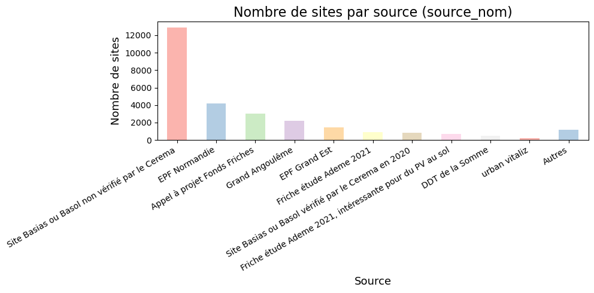

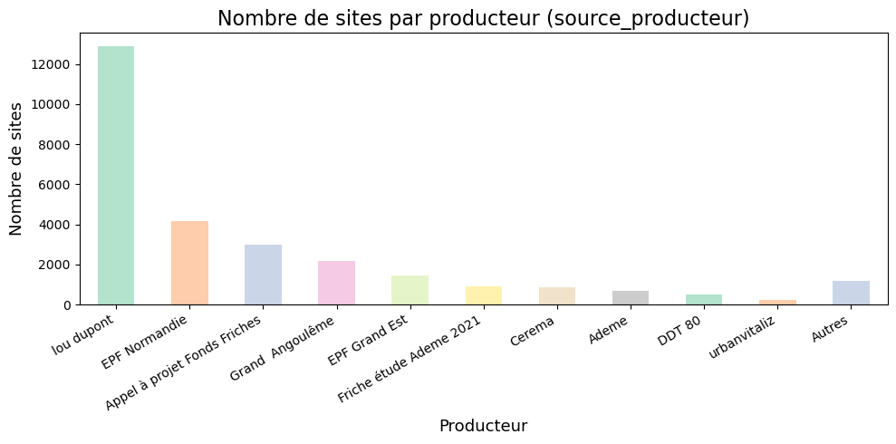

⚠️ Il serait intéressant de les revérifier redondances, il y a un mélange entre sources, type de saisie, et les opérations qui ont été réalisées par le cerema, comme les agrégations ou opérations manuelles? Refaire la distinction entre **fournisseur des données** et **source des donnée**

### Rôles dans la chaîne de la donnée

| **Rôle** | **Description** | **Exemples** |
| --- | --- | --- |
| **Producteur de données** | Génère directement la donnée primaire (observations, mesures, inventaire, etc.) | EPF, DDT, commune, IGN, DGFiP… |
| **Fournisseur / Source initiale** | Entité à l’origine de la donnée utilisée (même si indirecte ou reprise) | MAJIC, RPG, BASIAS, BASOL, DV3F, BD TOPO… |
| **Contributeur** | Acteur qui alimente une plateforme ou base, sans nécessairement produire les données en amont | Cerema, utilisateurs via UrbanVitaliz… |
| **Agrégateur** | Assemble, nettoie, structure et diffuse les données via une plateforme | Cartofriches, data.gouv.fr, Insee… |
| **Référent / Validateur** | Peut valider ou fiabiliser la donnée (vérification, croisement avec d’autres bases, cadrage méthodologique, etc.) | Cerema, Ademe, CNIG |

enrichissement possible et source des données

## 🧾 Audit Qualité

|  | Colonne | Type | Nb valeurs uniques | Top valeur | Fréquence top valeur | Nb de NaN | % de NaN |
| --- | --- | --- | --- | --- | --- | --- | --- |
| 0 | site_id | object | 28115 | 01001_32316 | 1.0 | 0 | 0.00 |
| 1 | site_nom | object | 24071 | Décharge | 415.0 | 0 | 0.00 |
| 2 | site_type | object | 19 | inconnu | 16005.0 | 0 | 0.00 |
| 3 | site_adresse | object | 3713 | LE VILLAGE | 30.0 | 24125 | 85.81 |
| 4 | site_identif_date | object | 581 | 2022-10-10 | 15736.0 | 0 | 0.00 |
| 5 | site_actu_date | object | 532 | 2022-10-10 | 15587.0 | 0 | 0.00 |
| 6 | site_url | object | 16939 | https://www.suippes.fr/9143-2/ | 14.0 | 11120 | 39.55 |
| 7 | site_ademe_url | float64 | 0 | None | NaN | 28115 | 100.00 |
| 8 | site_securite | object | 5 | inconnu | 20132.0 | 5822 | 20.71 |
| 9 | site_occupation | object | 20 | inconnu | 25850.0 | 0 | 0.00 |
| 10 | site_statut | object | 4 | friche potentielle | 13129.0 | 0 | 0.00 |
| 11 | site_projet_url | float64 | 0 | None | NaN | 28115 | 100.00 |
| 12 | site_reconv_annee | float64 | 0 | None | NaN | 28115 | 100.00 |
| 13 | site_reconv_type | object | 13 | habitat | 1100.0 | 25503 | 90.71 |
| 14 | activite_libelle | object | 1617 | Dépôt de liquides inflammables (D.L.I.) | 1821.0 | 13485 | 47.96 |
| 15 | activite_code | object | 109 | 4520A | 7.0 | 27961 | 99.45 |
| 16 | activite_fin_annee | object | 73 | 2010 | 315.0 | 24109 | 85.75 |
| 17 | comm_nom | object | 9390 | ANGOULEME | 697.0 | 132 | 0.47 |
| 18 | comm_insee | object | 9138 | 16015 | 697.0 | 132 | 0.47 |
| 19 | bati_type | object | 9 | inconnu | 25979.0 | 0 | 0.00 |
| 20 | bati_nombre | float64 | 106 | 1.0 | 11281.0 | 66 | 0.23 |
| 21 | bati_surface | float64 | 15 | 0.0 | 6.0 | 28095 | 99.93 |
| 22 | bati_pollution | object | 4 | inconnu | 26753.0 | 0 | 0.00 |
| 23 | bati_vacance | object | 5 | inconnu | 26007.0 | 0 | 0.00 |
| 24 | bati_patrimoine | object | 5 | inconnu | 25297.0 | 0 | 0.00 |
| 25 | bati_etat | object | 7 | inconnu | 22325.0 | 0 | 0.00 |
| 26 | local_ancien_annee | float64 | 323 | 1900.0 | 1153.0 | 12772 | 45.43 |
| 27 | local_recent_annee | float64 | 298 | 1900.0 | 1015.0 | 10694 | 38.04 |
| 28 | proprio_type | object | 1344 | X1a | 10389.0 | 313 | 1.11 |
| 29 | proprio_personne | object | 4 | personne morale | 16614.0 | 48 | 0.17 |
| 30 | proprio_nom | object | 12738 | _X_ | 10389.0 | 313 | 1.11 |
| 31 | sol_pollution_annee | float64 | 0 | None | NaN | 28115 | 100.00 |
| 32 | sol_pollution_existe | object | 7 | inconnu | 24816.0 | 0 | 0.00 |
| 33 | sol_pollution_origine | object | 4 | inconnu | 28085.0 | 0 | 0.00 |
| 34 | sol_pollution_commentaire | float64 | 0 | None | NaN | 28115 | 100.00 |
| 35 | sol_depollution_fiche | object | 3 | https://fiches-risques.brgm.fr/georisques/info... | 1.0 | 28112 | 99.99 |
| 36 | unite_fonciere_surface | float64 | 17319 | 187.0 | 24.0 | 63 | 0.22 |
| 37 | unite_fonciere_refcad | object | 26511 | {59512000AE0114,59512000AE0115,59512000AE0116,... | 18.0 | 37 | 0.13 |
| 38 | urba_zone_type | object | 10 | U | 15992.0 | 3953 | 14.06 |
| 39 | urba_zone_lib | object | 9058 | ZnC - Secteur non ouvert à la construction, sa... | 488.0 | 3953 | 14.06 |
| 40 | urba_zone_formdomi | object | 11 | Habitat | 1548.0 | 23579 | 83.87 |
| 41 | urba_doc_type | object | 5 | PLU | 12694.0 | 3851 | 13.70 |
| 42 | desserte_distance | float64 | 0 | None | NaN | 28115 | 100.00 |
| 43 | desserte_commentaire | float64 | 0 | None | NaN | 28115 | 100.00 |
| 44 | source_nom | object | 22 | Grand Angoulême | 2185.0 | 23077 | 82.08 |
| 45 | source_url | object | 12 | https://www.data.gouv.fr/fr/datasets/inventair... | 13751.0 | 6640 | 23.62 |
| 46 | source_producteur | object | 24 | Grand Angoulême | 2185.0 | 21534 | 76.59 |
| 47 | source_contact | object | 5 | infoterritoriale@grandangouleme.fr | 2185.0 | 25779 | 91.69 |
| 48 | geompoint | object | 26966 | POINT (3.175503 50.7054) | 18.0 | 0 | 0.00 |
| 49 | geomsurf | float64 | 0 | None | NaN | 28115 | 100.00 |

[interactive chart not shown]

### Répartition des Valeurs manquantes dans le temps

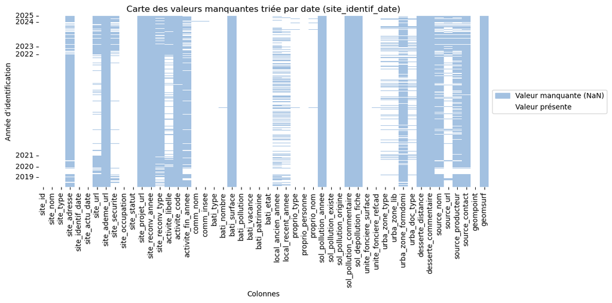

### Remplacement des valeurs inconnues

```
dtype('O')
```

[interactive chart not shown]

```
2022-10-10
2021-12-31
```

**Commentaire:** Les données ci dessus montrent la répartition des Na dans le temps, on constate une zone entre 12/2021 10/2022 ou la complétude de certainnes données comme **`site_url`, `site_securite`, `activite_libelle`** sont plus importantes ⚠️problématique qui gére ces données, y a t 'il une maintenance automatique y a t'il des observatoires qui complètent moins bien

⚠️définir les critères d'exploitabilité et de qualité par rapport a ML ou audit qualité ou mix

## 📊 Analyse métier et qualité

**La complétude, l'unicité, la pertinence, la validité, ainsi que la criticité** de chaque variable est analysée dans un premier temps pour évaluerla qualité générale des données fournies par cartofriche et leur provenance, cette analyse exhaustive permet un mapping des données, une navigation plus simple pour les détails. Mais aussi la compréhension métier de chaque variable, ce qui est critique pour l'évaluation de la pertinence.

Le dataset a été séparé en plusieurs dataframe, une catégorisation mixte prioritairement

- métier, par catégorie ou provenance propable, le travail a été déjà grandement facilité par l'ajout des préfixes
- fonctionelle: les données ayant la même fonction comme les localisations, les données de surface, les données temporelles

### Dictionnaire des variables

### Fonction d'audit

$$\text{Valeurs Manquantes Réelles} = \sum_{i=1}^{N} \mathbb{I}(\text{valeur}_i \text{ est } \text{NaN ou None})$$$$\text{Valeurs Manquantes Effectives} = \sum_{i=1}^{N} \mathbb{I}(\text{valeur}_i \text{ est NaN/None ou un synonyme de manquant})$$$$ \text{Taux de Doublons (\%)} = \left( \frac{\text{Nombre de Lignes Dupliquées dans la Colonne}}{\text{Nombre Total de Lignes dans la Colonne}} \right) \times 100 $$$$ \text{Dominance (\%)} = \left( \frac{\text{Compte de la Modalité la Plus Fréquente}}{\text{Nombre Total de Valeurs Non-Manquantes Effectives}} \right) \times 100 $$$$\text{Nb Valeurs Uniques} = \text{Nombre de } \{ \text{valeur} \mid \text{valeur est unique et non manquante effective} \}$$$$\text{Nb Lignes Valides Selon Règle} = \sum_{i=1}^{N} \mathbb{I}(\text{valeur}_i \text{ respecte la règle ET n'est pas manquante effective})$$$$\text{Taux de Validité Effectif (\%)} = \left( \frac{\text{Nb Lignes Valides Selon Règle}}{\text{Nombre Total de Lignes} - \text{Valeurs Manquantes Effectives}} \right) \times 100$$

### Fonction de tri métier

### Fonction de detection des outliers et modalités invalides

### Fonction de Transformation des dates et gestions des outliers

### 🏷️ Informations générales

L'analyse de la qualité de ces données fait ressortir plusieurs points de vigilance sur les données information:  
**'`site_id`', '`site_nom`', '`site_type`', '`site_statut`', '`site_occupation`'**  
• Valeurs manquantes : De nombreuses entrées présentent des valeurs non renseignées dans certains champs (par exemple, absence d'information pour le statut d'un site ou sa taille). Certains attributs clés sont incomplets pour une proportion significative des sites.  
• Doublons potentiels : On observe des cas où des sites semblent apparaître en double (même nom ou mêmes coordonnées GPS). Ceci peut provenir de la fusion de plusieurs sources de données – un même site ayant pu être inventorié plusieurs fois.  
• Types de données et formats : Quelques incohérences de format existent, par exemple des codes chiffrés stockés comme du texte, ou des catégorisations divergentes pour un même champ selon les sources (nécessitant une harmonisation).  
• Distribution déséquilibrée : Certaines variables catégorielles sont dominées par une modalité unique. Par exemple, si la majorité des friches sont d’un seul type d’usage industriel, cela crée un déséquilibre pouvant biaiser les analyses.  
**Interprétation et recommandations** : Ces constats soulignent des défis pour la fiabilité des analyses. Les valeurs manquantes indiquent qu'une partie de l'information est indisponible, ce qui peut limiter les conclusions ou nécessiter des méthodes d'imputation. La présence de doublons suggère de dédupliquer les données afin d’éviter de compter plusieurs fois le même site et d’obtenir des statistiques correctes. Les problèmes de format (types inadéquats, libellés incohérents) doivent être corrigés pour assurer une interprétation correcte des variables (par exemple convertir les champs numériques au bon format, uniformiser les catégories de classification). Enfin, la domination d’une seule catégorie dans certains champs invite à la prudence : elle peut refléter un biais de collecte (p. ex. un inventaire centré sur un certain type de friche) et nécessite de nuancer l’analyse ou d’enrichir les données pour mieux représenter les autres cas.

|  | colonne | valeur_manquant_reel | valeur_manquant_effectif | taux_doublons_(%) | Modalite_Dominante | Dominance_(%) | Nb_Valeurs_Uniques | Nb_Lignes_Valides_Selon_Regle | Taux_Validite_Effectif_(%) | Top3_Modalites_Non_Valides |
| --- | --- | --- | --- | --- | --- | --- | --- | --- | --- | --- |
| 0 | site_id | 0 | 0 | 0.00 | 17300_11257 | 0.0 | 28115 | 28115 | 100.00 | Aucune |
| 1 | site_nom | 0 | 5 | 14.38 | Décharge | 1.5 | 24069 | 28110 | 100.00 | Aucune |
| 2 | site_type | 0 | 17229 | 99.93 | friche d'habitat | 36.6 | 17 | 10885 | 99.99 | {'inconnu': 16005, 'autre': 1224, 'friche tour... |
| 3 | site_statut | 0 | 0 | 99.99 | friche potentielle | 46.7 | 4 | 28115 | 100.00 | Aucune |
| 4 | site_occupation | 0 | 25850 | 99.93 | friche d'habitat | 71.0 | 19 | 118 | 5.21 | {'inconnu': 25850, 'friche d'habitat': 1608, '... |
| 5 | site_reconv_type | 25503 | 25784 | 99.95 | habitat | 47.2 | 11 | 2303 | 98.80 | {'nan': 25503, 'inconnu': 225, 'autre': 56} |
| 6 | TOTAL DOMAINE | 25503 | 68868 | 69.03 | N/A | N/A | N/A | 97646 | 97.82 | N/A |

site_id Exploitable

#### `site_id` (identifiant unique)

Aucune valeur manquante (0%) et chaque identifiant semble unique. La qualité est bonne sur ce champ. On ne constate pas de doublon évident ni d’anomalie sur le format.  
**Causes potentielles** : Ce champ est généré lors de l’intégration des données, il est bien géré en interne.  
**Recommandation** : Maintenir l’unicité en contrôlant les doublons lors des imports. Documenter le format de l’identifiant (concaténation de codes) pour lever toute ambiguïté.

|  | Pattern typologique | Longueur | Exemple | Fréquence |
| --- | --- | --- | --- | --- |
| 5 | 00000_00000 | 11 | 61214_34555 | 18750 |
| 4 | 00000_0000 | 10 | 62178_4393 | 8128 |
| 3 | 00000_000 | 9 | 16154_221 | 869 |
| 9 | AA_00000 | 8 | NA_35083 | 131 |
| 8 | 0A000_00000 | 11 | 2A028_15474 | 113 |
| 2 | 00000_00 | 8 | 76312_61 | 83 |
| 7 | 0A000_0000 | 10 | 2B185_1532 | 30 |
| 1 | 00000_0 | 7 | 08363_1 | 9 |
| 0 | 00000X00000_00000 | 17 | 54286,54136_35164 | 1 |
| 6 | 0A000_000 | 9 | 2B082_112 | 1 |

⚠️voir le rapport entre les typologies et la provenance ou signification de la typologie

site_nom À surveiller